```python
import numpy as np
import pandas as pd
import matplotlib.pyplot as plt
import seaborn as sns
import warnings

%matplotlib inline
warnings.filterwarnings('ignore')
```

## 가설 1. 행복한 나라와 덜 행복한 나라간의 여러 컬럼간의 격차가 클 것이다.

```
상위 30개 국의 자유도 0.8853666666666666
전체 나라의 자유도 0.7915973154362417
```

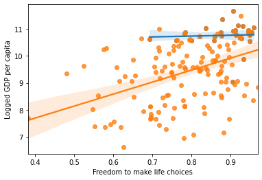

```python
# 상위 30위안의 나라들의 경제적인 수준과 자유도를 분석
d=pd.read_csv("./world-happiness-report-2021.csv")
d=d.iloc[:,:13]
f_d=pd.read_csv("./world-happiness-report.csv")
d.head()


t1=d.nlargest(30,'Ladder score')[::-1]


print("상위 30개 국의 자유도",t1['Freedom to make life choices'].mean())
print("전체 나라의 자유도",d['Freedom to make life choices'].mean())


t1_freedom=t1['Freedom to make life choices']
t1_gdp=t1['Logged GDP per capita']


sns.regplot(x=t1_freedom,y=t1_gdp)


sns.regplot(x=d['Freedom to make life choices'],y=d['Logged GDP per capita'])
```

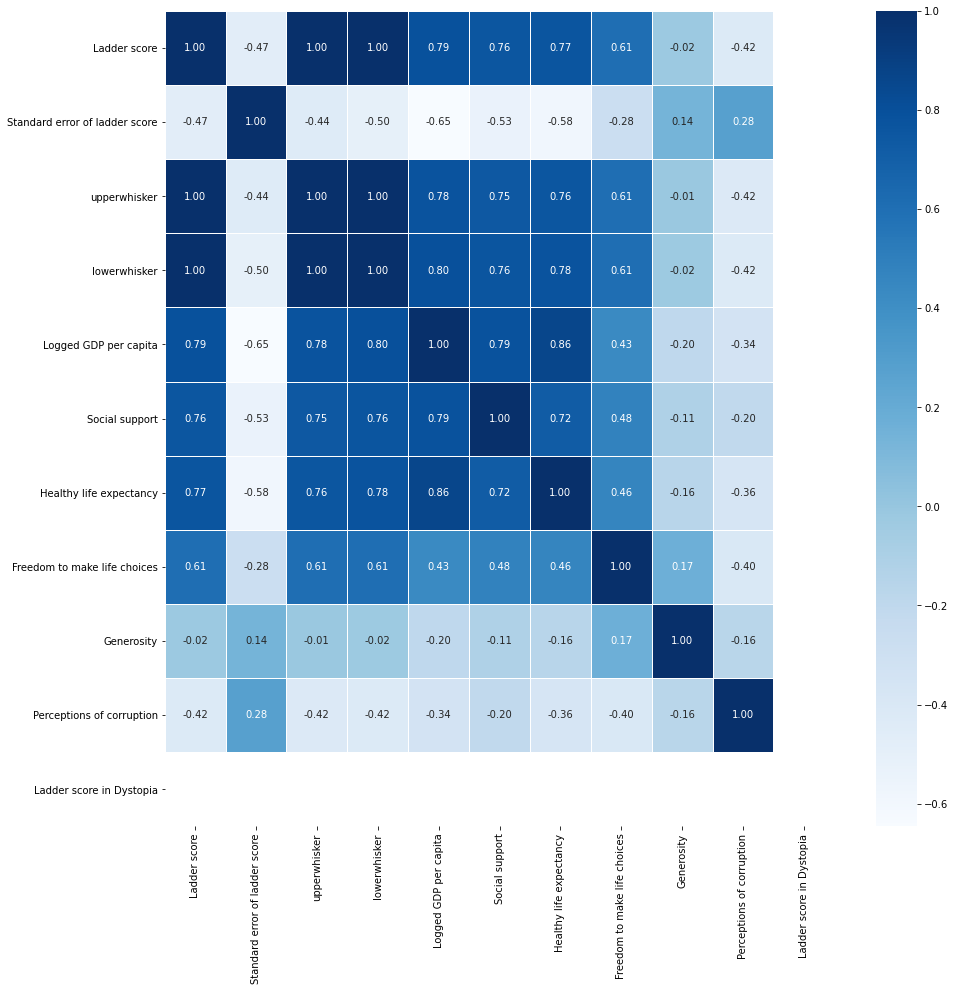

```python
# 히트맵을 통해 상관계수 조사
f_d[f_d['Country name']=='Finland']
d.corr()
plt.figure(figsize=(15,15))
sns.heatmap(data=d.corr(),annot=True,fmt='.2f',linewidths=.5,cmap='Blues')
plt.show()
```

- 지역별 건강 기대 수명과 경제적 수준 분포도

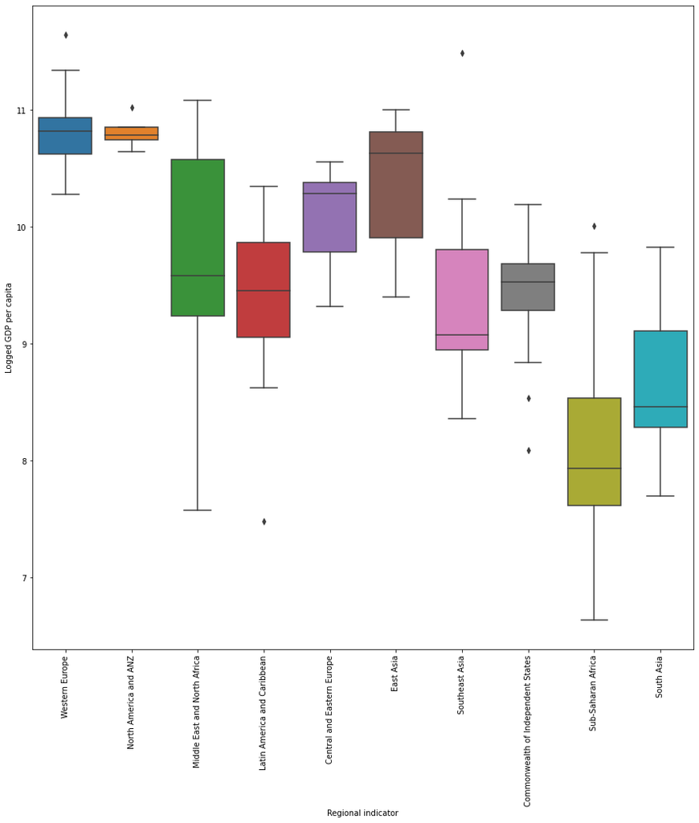

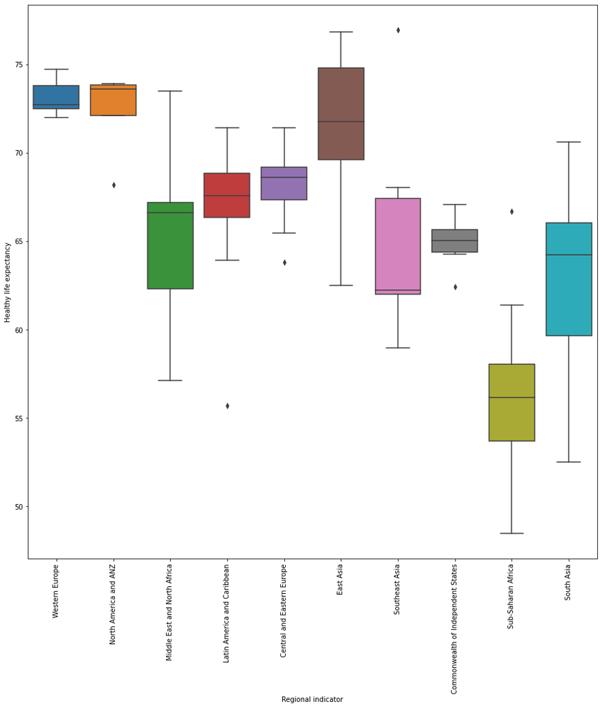

```python
plt.figure(figsize=(15,15))
sns.boxplot(x=d['Regional indicator'],y=d['Logged GDP per capita'])
plt.xticks(rotation=90)

plt.figure(figsize=(15,15))
sns.boxplot(x=d['Regional indicator'],y=d['Healthy life expectancy'])
plt.xticks(rotation=90)
plt.show()
```

#### 지역별 행복 분포도

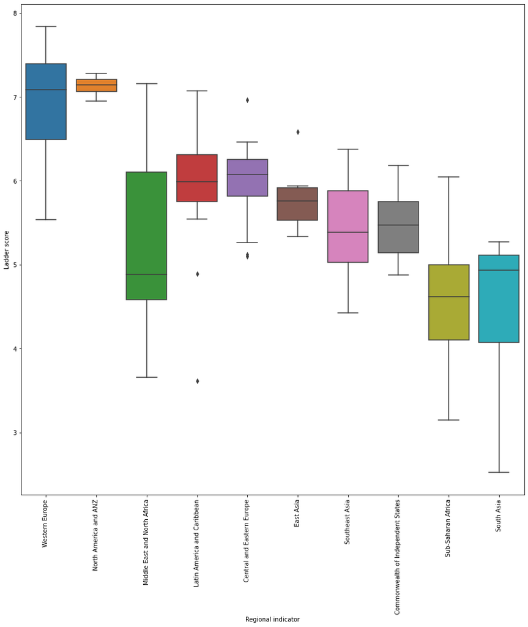

```python
plt.figure(figsize=(15,15))
sns.boxplot(x=d['Regional indicator'],y=d['Ladder score'])
plt.xticks(rotation=90)
plt.show()
```

### ※상관계수가 큰 변수들 그래프로 그려봤을 때 동아시아는 두 가지 변수의 값이 평균적으로 높지만 높지 못한 행복도를 보인다.

```python
print(t1.mean())
print("----")
print(d[d['Regional indicator']=='East Asia'].mean())
```

```
Ladder score                       7.022967
Standard error of ladder score     0.042700
upperwhisker                       7.106667
lowerwhisker                       6.939267
Logged GDP per capita             10.754133
Social support                     0.921567
Healthy life expectancy           71.836600
Freedom to make life choices       0.885367
Generosity                         0.015000
Perceptions of corruption          0.544300
Ladder score in Dystopia           2.430000
dtype: float64
----
Ladder score                       5.810333
Standard error of ladder score     0.040000
upperwhisker                       5.889500
lowerwhisker                       5.731667
Logged GDP per capita             10.367667
Social support                     0.860500
Healthy life expectancy           71.252167
Freedom to make life choices       0.763500
Generosity                        -0.062333
Perceptions of corruption          0.683333
Ladder score in Dystopia           2.430000
dtype: float64
```

## 가설 2. 상위권 나라와 하위권 나라의 점수 분포가 반대될 것이다.

```python
# happiness_report 불러오기
happy_df = pd.read_csv('./world-happiness-report-2021.csv')
happy_df
```

|  | Country name | Regional indicator | Ladder score | Standard error of ladder score | upperwhisker | lowerwhisker | Logged GDP per capita | Social support | Healthy life expectancy | Freedom to make life choices | Generosity | Perceptions of corruption | Ladder score in Dystopia | Explained by: Log GDP per capita | Explained by: Social support | Explained by: Healthy life expectancy | Explained by: Freedom to make life choices | Explained by: Generosity | Explained by: Perceptions of corruption | Dystopia + residual |
| --- | --- | --- | --- | --- | --- | --- | --- | --- | --- | --- | --- | --- | --- | --- | --- | --- | --- | --- | --- | --- |
| 0 | Finland | Western Europe | 7.842 | 0.032 | 7.904 | 7.780 | 10.775 | 0.954 | 72.000 | 0.949 | -0.098 | 0.186 | 2.43 | 1.446 | 1.106 | 0.741 | 0.691 | 0.124 | 0.481 | 3.253 |
| 1 | Denmark | Western Europe | 7.620 | 0.035 | 7.687 | 7.552 | 10.933 | 0.954 | 72.700 | 0.946 | 0.030 | 0.179 | 2.43 | 1.502 | 1.108 | 0.763 | 0.686 | 0.208 | 0.485 | 2.868 |
| 2 | Switzerland | Western Europe | 7.571 | 0.036 | 7.643 | 7.500 | 11.117 | 0.942 | 74.400 | 0.919 | 0.025 | 0.292 | 2.43 | 1.566 | 1.079 | 0.816 | 0.653 | 0.204 | 0.413 | 2.839 |
| 3 | Iceland | Western Europe | 7.554 | 0.059 | 7.670 | 7.438 | 10.878 | 0.983 | 73.000 | 0.955 | 0.160 | 0.673 | 2.43 | 1.482 | 1.172 | 0.772 | 0.698 | 0.293 | 0.170 | 2.967 |
| 4 | Netherlands | Western Europe | 7.464 | 0.027 | 7.518 | 7.410 | 10.932 | 0.942 | 72.400 | 0.913 | 0.175 | 0.338 | 2.43 | 1.501 | 1.079 | 0.753 | 0.647 | 0.302 | 0.384 | 2.798 |
| ... | ... | ... | ... | ... | ... | ... | ... | ... | ... | ... | ... | ... | ... | ... | ... | ... | ... | ... | ... | ... |
| 144 | Lesotho | Sub-Saharan Africa | 3.512 | 0.120 | 3.748 | 3.276 | 7.926 | 0.787 | 48.700 | 0.715 | -0.131 | 0.915 | 2.43 | 0.451 | 0.731 | 0.007 | 0.405 | 0.103 | 0.015 | 1.800 |
| 145 | Botswana | Sub-Saharan Africa | 3.467 | 0.074 | 3.611 | 3.322 | 9.782 | 0.784 | 59.269 | 0.824 | -0.246 | 0.801 | 2.43 | 1.099 | 0.724 | 0.340 | 0.539 | 0.027 | 0.088 | 0.648 |
| 146 | Rwanda | Sub-Saharan Africa | 3.415 | 0.068 | 3.548 | 3.282 | 7.676 | 0.552 | 61.400 | 0.897 | 0.061 | 0.167 | 2.43 | 0.364 | 0.202 | 0.407 | 0.627 | 0.227 | 0.493 | 1.095 |
| 147 | Zimbabwe | Sub-Saharan Africa | 3.145 | 0.058 | 3.259 | 3.030 | 7.943 | 0.750 | 56.201 | 0.677 | -0.047 | 0.821 | 2.43 | 0.457 | 0.649 | 0.243 | 0.359 | 0.157 | 0.075 | 1.205 |
| 148 | Afghanistan | South Asia | 2.523 | 0.038 | 2.596 | 2.449 | 7.695 | 0.463 | 52.493 | 0.382 | -0.102 | 0.924 | 2.43 | 0.370 | 0.000 | 0.126 | 0.000 | 0.122 | 0.010 | 1.895 |

149 rows × 20 columns

```python
# 행복지수 순 중의 상위5 개와 하위 5개
happy_df = happy_df.sort_values(by='Ladder score', ascending=False)
happy = happy_df.head(5)
unhappy = happy_df.tail(5)
```

```python
#필요한 column만 평균 구하기
happy_mean = happy.iloc[:, [2, 6, 7, 8, 9, 10, 11]].mean()
unhappy_mean = unhappy.iloc[:, [2, 6, 7, 8, 9, 10, 11]].mean()
```

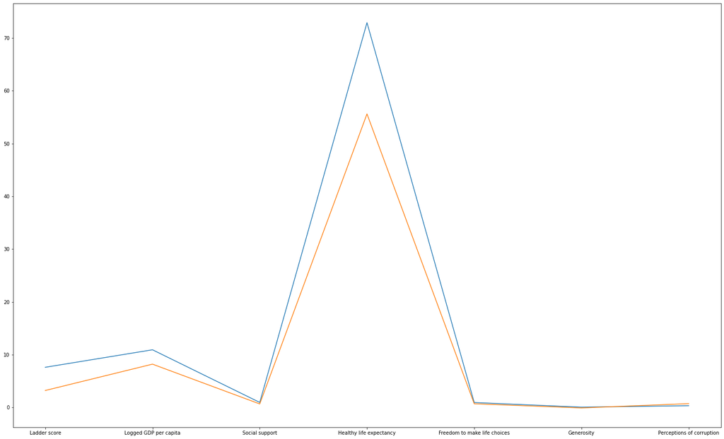

```python
# 상위 5개 나라와 하위 5개 나라의 각 항목별 수치 평균 그래프
plt.figure(figsize=(26, 16))
plt.plot(happy_mean)
plt.plot(unhappy_mean)
plt.show()
```